# Lab 11 - Stats 503

PITCHf/x data from MLB. Contains variables:

- `start_speed`: Initial speed in mph
- `pfx_x`, `pfx_z`: Horizontal and vertical movement relative to a ball thrown with zero spin.
- `x0`, `z0`: Horizontal and vertical location of the release point of the pitch.

```r
require(ggplot2)
require(reshape2)
require(gridExtra)

# require(pitchRx)
# require(plyr)
# rawdat = scrape(start = "2016-10-01", end = "2016-10-01")
# vars_pitch = c('start_speed', 'pfx_x', 'pfx_z', 'x0', 'z0', 'num', 'url')
# vars_atbat = c('num', 'url', 'p_throws')

# dat = join(rawdat$atbat[,vars_atbat], rawdat$pitch[,vars_pitch],
#             by=c('num', 'url'), type='inner')
# dat = dat[complete.cases(dat),]
# dat = dat[1:1500,]

# keepvars = c('start_speed', 'pfx_x', 'pfx_z', 'x0', 'z0')
# write.csv(dat[,keepvars], file='./data/pitches.txt', row.names=FALSE)

dat = read.csv('./data/pitches.txt')
```

## Visualization

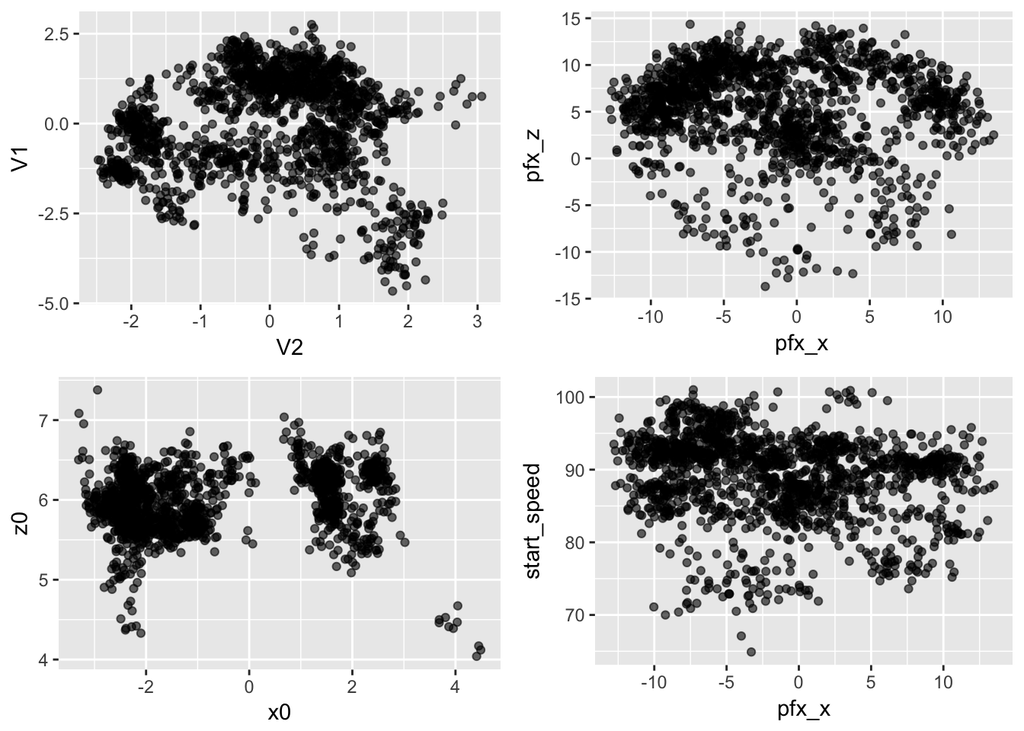

```r
dat_norm = scale(dat)
dis = dist(dat_norm)
mds = as.data.frame(cmdscale(dis, k=2))

q1 = ggplot(mds, aes(x=V2, y=V1)) + geom_point(alpha=0.6)
q2 = ggplot(dat, aes(x=pfx_x, y=pfx_z)) + geom_point(alpha=0.6)
q3 = ggplot(dat, aes(x=x0, y=z0)) + geom_point(alpha=0.6)
q4 = ggplot(dat, aes(x=pfx_x, y=start_speed)) + geom_point(alpha=0.6)
grid.arrange(q1, q2, q3, q4, ncol=2)
```

## Hierarchical Clustering

Packages:

- `hclust` in base R.
- `agnes` in the `cluster` package.

```r
require(cluster)

pitch_sing = agnes(dat_norm, diss=FALSE, method='single')
pitch_comp = agnes(dat_norm, diss=FALSE, method='complete')
pitch_ward = agnes(dat_norm, diss=FALSE, method='ward')

sil_sing = silhouette(cutree(pitch_sing, k=5), dis)
sil_comp = silhouette(cutree(pitch_comp, k=5), dis)
sil_ward = silhouette(cutree(pitch_ward, k=5), dis)
```

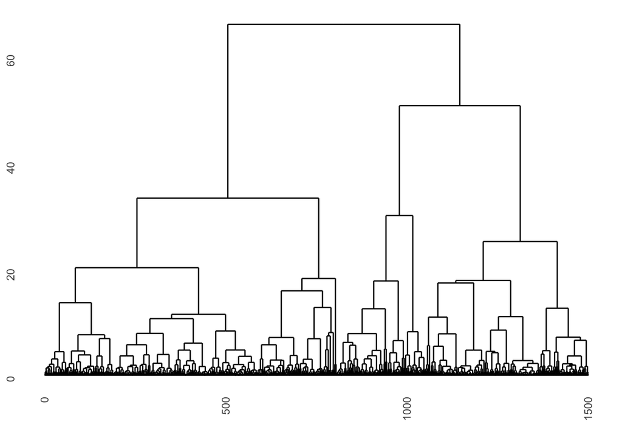

```r
require(ggdendro)

# plot(pitch_sing)

# ggdendrogram(as.dendrogram(pitch_sing), leaf_labels=FALSE, labels=FALSE)
# summary(sil_sing)
# plot(sil_sing)

# ggdendrogram(as.dendrogram(pitch_comp), leaf_labels=FALSE, labels=FALSE)
# summary(sil_comp)
# plot(sil_comp)

ggdendrogram(as.dendrogram(pitch_ward), leaf_labels=FALSE, labels=FALSE)
```

```r
summary(sil_ward)
```

```
## Silhouette of 1500 units in 5 clusters from silhouette.default(x = cutree(pitch_ward, k = 5), dist = dis) :
##  Cluster sizes and average silhouette widths:
##       586       188       219       451        56
## 0.3540115 0.2770077 0.1563622 0.2996400 0.6021177
## Individual silhouette widths:
##    Min. 1st Qu.  Median    Mean 3rd Qu.    Max.
## -0.3542  0.2219  0.3244  0.3084  0.4336  0.7153
```

[figure not shown]

```r
plot(sil_ward)
```

## Exploring numbers of clusters

https://rogerfan.shinyapps.io/lab11-shiny/

## K-Means

We can use the built-in function `kmeans` to do k-means clustering. The basic algorithm can be selected with the option `algorithm='Lloyd'`, but the default algorithm has several optimizations that result in better performance.

K-means is very sensitive to initial values, so as a rule always use multiple starts and choose the best one.

```r
# ?kmeans
set.seed(23462)

clust_kmeans = kmeans(dat_norm, 5, iter.max=100, algorithm='Lloyd')
clust_kmeans = kmeans(dat_norm, 5)
clust_kmeans
```

```
## K-means clustering with 5 clusters of sizes 241, 417, 189, 76, 577
##
## Cluster means:
##   start_speed      pfx_x      pfx_z         x0          z0
## 1 -0.46992441 -0.6839588 -0.3716475 -0.4855440 -1.12345557
## 2  0.07668955  1.0538029  0.3780520  1.3076582  0.30312740
## 3 -0.96604621  0.6901454 -1.1512798 -0.7807431  0.44635025
## 4 -2.32628988 -0.2599254 -2.3154542  1.1283406  1.25769079
## 5  0.76369672 -0.6677381  0.5641002 -0.6351313 -0.06169156
##
## Clustering vector:
##    [1] 5 5 5 5 5 5 5 5 5 3 5 3 3 5 5 5 3 3 5 3 3 5 3 3 5 5 5 3 5 3 3 5 5 5
##   [35] 5 3 5 3 3 5 3 5 3 3 3 3 3 5 5 5 5 5 5 3 3 5 5 5 5 3 5 5 3 3 3 5 3 5
##   [69] 5 3 5 3 3 5 5 3 3 3 5 5 1 1 5 5 1 5 5 1 1 1 5 1 1 1 1 5 5 1 1 1 1 1
##  [103] 1 1 5 5 3 3 5 3 5 3 3 5 5 5 3 5 5 3 5 5 5 5 3 5 5 2 2 2 2 2 2 2 2 2
```

[output cut: 51 more lines]

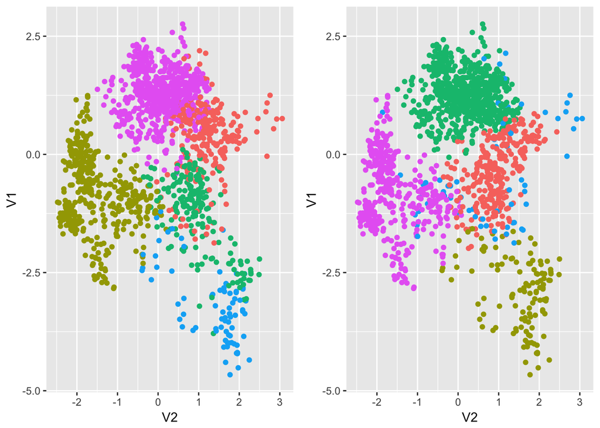

```r
set.seed(625723)  # For a bad example
clust_kmeans2 = kmeans(dat_norm, 5)

mds_temp = cbind(
    mds, as.factor(clust_kmeans$cluster), as.factor(clust_kmeans2$cluster))
names(mds_temp) = c('V1', 'V2', 'clust1', 'clust2')

gp1 = ggplot(mds_temp, aes(x=V2, y=V1, color=clust1)) +
    geom_point() + theme(legend.position="none")
gp2 = ggplot(mds_temp, aes(x=V2, y=V1, color=clust2)) +
    geom_point() + theme(legend.position="none")
grid.arrange(gp1, gp2, ncol=2)
```

```r
clust_kmeans$tot.withinss
```

```
## [1] 2935.271
```

```r
clust_kmeans2$tot.withinss
```

```
## [1] 3056.969
```

```r
clust_kmeans$betweenss
```

```
## [1] 4559.729
```

```r
clust_kmeans2$betweenss
```

```
## [1] 4438.031
```

## K-Means++

A smarter way of initializing K-Means that usually results in better performance. An implementation is available in the `flexclust` package, but the basic algorithm is easy to implement.

The algorithm is:

- For each data point, compute the distance to the nearest existing center.
- Choose a new data point at random to be a center, weighting the draw so the probability that a point is chose is proportional to its squared distance.
- Repeat until K centers are chosen.
- Apply K-means with those centers as the initial ones.

This usually performs better and more consistently than K-means, but you should still use multiple initializations.

```r
require(matrixStats)

kpp_init = function(dat, K) {
    x = as.matrix(dat)
    n = nrow(x)

    # Randomly choose a first center
    centers = matrix(NA, nrow=K, ncol=ncol(x))
    centers[1,] = as.matrix(x[sample(1:n, 1),])

    for (k in 2:K) {
        # Calculate dist^2 to closest center for each point
        dists = matrix(NA, nrow=n, ncol=k-1)
        for (j in 1:(k-1)) {
            temp = sweep(x, 2, centers[j,], '-')
            dists[,j] = rowSums(temp^2)
        }
        dists = rowMins(dists)

        # Draw next center with probability propor to dist^2
        cumdists = cumsum(dists)
        prop = runif(1, min=0, max=cumdists[n])
        centers[k,] = as.matrix(x[min(which(cumdists > prop)),])
    }
    return(centers)
}

clust_kpp = kmeans(dat_norm, kpp_init(dat_norm, 5), iter.max=100, algorithm='Lloyd')
```

## Exercise: Gaussian Mixture Models

- Generate a 2-d dataset with 50 points from a $N((0, 0), 6 \times I)$ distribution, 50 from a $N((4, 4), 0.1 \times I)$, and 50 from a $N((-4, 0), 0.1 \times I)$.
- Fit a Gaussian mixture model on the data and generate cluster labels. To do this, investigate the `mvnormalmixEM` function in the package `mixtools`. Keep in mind that GMM can be sensitive to initial values. To generate the labels, use `$posterior` from the result.
- Fit a K-means model on the data and generate cluster labels.
- Plot the results from both models side-by-side. Comment on the results.